# R Notebook_Random Variables Exercises

import data into R

```r
library(downloader)
url <- "https://raw.githubusercontent.com/genomicsclass/dagdata/master/inst/extdata/femaleControlsPopulation.csv"
filename <- basename(url)
download(url, destfile=filename)
x <- unlist( read.csv(filename) )
View(x)
head(x)
```

```
Bodyweight1 Bodyweight2 Bodyweight3 Bodyweight4 Bodyweight5 Bodyweight6
      27.03       24.80       27.02       28.07       23.55       22.72
```

1. What is the average of these weights?
2. After setting the seed at 1, set.seed(1) take a random sample of size 5. What is the absolute value (use abs) of the difference between the average of the sample and the average of all the values?
3. After setting the seed at 5, set.seed(5) take a random sample of size 5. What is the absolute value of the difference between the average of the sample and the average of all the values?

```r
bodyweights_mean<-mean(x)

cat("The average weight of the population is:", bodyweights_mean, "\n")
```

```
The average weight of the population is: 23.89338
```

```r
set.seed(1)
control<-sample(x,5)
mean_difference<-abs(mean(control)-bodyweights_mean)
mean_difference
```

```
[1] 0.3293778
```

```r
set.seed(5)
control_1<-sample(x,5)
mean_difference_1<-abs(mean(control_1)-bodyweights_mean)
mean_difference_1
```

```
[1] 0.3813778
```

5.Set the seed at 1, then using a for-loop take a random sample of 5 mice 1,000 times. Save these averages. What percent of these 1,000 averages are more than 1 ounce away from the average of x ?

```r
set.seed(1)
n <- 1000
null <- numeric(n)

for (i in 1:n) {
  control_2 <- sample(x, 5)
  null[i] <- abs(mean(control_2) - mean(x))
}

percentage_bigger_than <- mean(null > 1) * 100

percentage_bigger_than
```

```
[1] 50.3
```

6.We are now going to increase the number of times we redo the sample from 1,000 to 10,000. Set the seed at 1, then using a for-loop take a random sample of 5 mice 10,000 times. Save these averages. What percent of these 10,000 averages are more than 1 ounce away from the average of x ?

```r
set.seed(1)
n<-10000
null<-numeric(n)

for (i in 1:n){
  control_3<-sample(x,5)
  null[i]<-mean(control_3)-mean(x)
}

percentage_bigger_than_1<-mean(null>1)*100

percentage_bigger_than_1
```

```
[1] 24.48
```

Set the seed at 1, then using a for-loop take a random sample of 50 mice 1,000 times. Save these averages. What percent of these 1,000 averages are more than 1 ounce away from the average of x ?

```r
set.seed(1)
n<-1000

null<-numeric(n)

for (i in 1:n){
  control_4<-sample(x,50)
  null[i]<-mean(control_4)-mean(x)

}

percentage_bigger_than_2<-mean(null>1)*100
percentage_bigger_than_2
```

```
[1] 0.9
```

8. Use a histogram to “look” at the distribution of averages we get with a sample size of 5 and a sample size of 50.

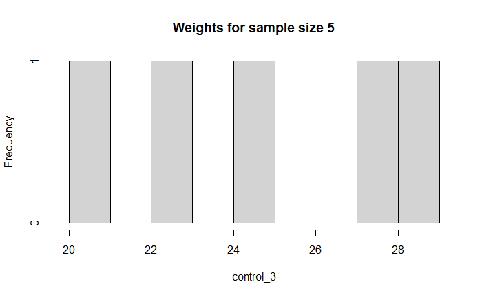

```r
set.seed(1)
n <- 1000
null <- numeric(n)

for (i in 1:n) {
  control_3 <- sample(x, 5)
  sample_mean_3 <- mean(control_3)
  null[i] <- abs(sample_mean_3 - mean(x))
}

percentage_bigger_than_1_ounce <- mean(null > 1) * 100

smallest_3 <- floor(min(control_3))
largest_3 <- ceiling(max(control_3))
bins_3 <- seq(smallest_3, largest_3)
hist(control_3, breaks = bins_3, main = "Weights for sample size 5")
```

```r
NA
NA
```

[figure not shown]

```r
set.seed(1)
n <- 1000
null <- numeric(n)

for (i in 1:n) {
  control_4 <- sample(x, 50)
  sample_mean_4 <- mean(control_4)
  null[i] <- abs(sample_mean_4 - mean(x))
}

percentage_bigger_than_1_ounce <- mean(null > 1) * 100


smallest_4 <- floor(min(control_4))
largest_4 <- ceiling(max(control_4))
bins_3 <- seq(smallest_4, largest_4)
hist(control_4, breaks = bins_4, main = "Weights for sample size 50")
```

```r
NA
NA
NA
NA
```

9. For the last set of averages, the ones obtained from a sample size of 50, what percent are between 23 and 25?

```r
set.seed(1)
n<-1000
null<-numeric(n)
count_between_23_and_25<-0

for (i in 1:n){
  control_4<-sample(x,50)
  sample_mean_4<-mean(control_4)
  null[i]<-sample_mean_4

  if (sample_mean_4>=23 && sample_mean_4<=25) {
    count_between_23_and_25<-count_between_23_and_25+1
  }
}
percentage_between_23_and_25<-(count_between_23_and_25)/n*100
percentage_between_23_and_25
```

```
[1] 98.2
```

10. Now ask the same question of a normal distribution with average 23.9 and standard deviation 0.43.

```r
set.seed(1)
n<-1000
null<-numeric(n)
count_between_23_25<-0

for (i in 1:n){
  control_5<-rnorm(50,mean=23.9,sd=0.43)
  sample_mean_5<-mean(control_5)
  null[i]<-sample_mean_5

  if (sample_mean_5>=23 && sample_mean_5<=25){
    count_between_23_25<-count_between_23_25+1
  }
}
percentage_between_23_25_normal<-(count_between_23_25)/n*100
percentage_between_23_25_normal
```

```
[1] 100
```